# Shiny / dashboard: going further… and deploy

## Before we start…

\(\rightarrow\) **LAST SESSIONS ?** BONUS material!

Once Shiny is covered, I like to extend to the realm of R capabilities:

- **geocomputation**: handling maps - you can integrate them in Shiny!
- **third party data**: retrieving sets fro APIs (e.g.: twitter) + a bit of text mining (always useful)
- **clustering & supervised learning**: very powerful when used correctly

**BUT:** other options are possible:

- **mentoring**: help on your projects (needed?, needed!)
- **a use case**: a short tour on how I build small apps
- **Python integration in RStudio**
- **inference, testing, Granger causality**
- **open to suggestions**: go on & propose!

## Key reminder: basic data science functions (tidyverse)

- **data wrangling**: **select**() keeps only some columns, **filter**() keeps rows depending on some conditions, **mutate**() creates new columns (see Session 1).
- **pivot tables**: perform an analysis on subgroups to simplify the data. **group_by**() defines the groups and **summarize**() the indicator (usually: mean(something) or n()).

```r
diamonds %>%
  group_by(cut) %>%
  summarise(avg_size = mean(carat))
```

|  | cut | avg_size |
| --- | --- | --- |
| 1 | Fair | 1.04613664596273 |
| 2 | Good | 0.849184671830412 |
| 3 | Very Good | 0.806381393808972 |
| 4 | Premium | 0.891954898121964 |
| 5 | Ideal | 0.702836991322908 |

## Look at column **names**:

```r
diamonds %>%
  group_by(cut, clarity) %>%
  summarise(nb_diamonds = n(),
            avg_price = mean(price) %>% round(2))
```

|  | cut | clarity | nb_diamonds | avg_price |
| --- | --- | --- | --- | --- |
| 1 | Fair | I1 | 210 | 3703.53 |
| 2 | Fair | SI2 | 466 | 5173.92 |
| 3 | Fair | SI1 | 408 | 4208.28 |
| 4 | Fair | VS2 | 261 | 4174.72 |
| 5 | Fair | VS1 | 170 | 4165.14 |
| 6 | Fair | VVS2 | 69 | 3349.77 |
| 7 | Fair | VVS1 | 17 | 3871.35 |
| 8 | Fair | IF | 9 | 1912.33 |
| 9 | Good | I1 | 96 | 3596.64 |
| 10 | Good | SI2 | 1081 | 4580.26 |

[output cut: 30 more lines]

## Key reminder: INSIGHT!

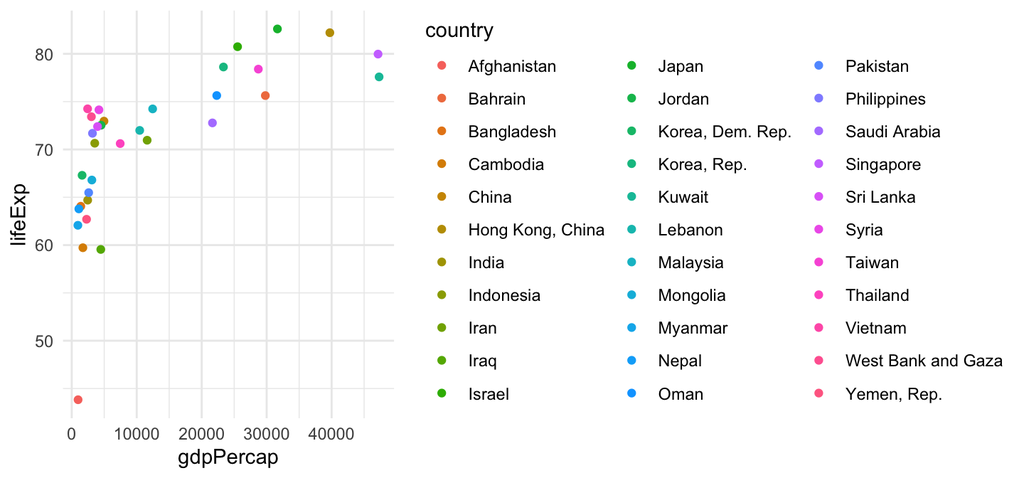

```r
library(gapminder)
gapminder %>%
    filter(year == 2007, continent == "Asia") %>%
    ggplot(aes(x = gdpPercap, y = lifeExp, color = country)) +
    geom_point() + theme_minimal() +
    guides(color = guide_legend(ncol = 3))
```

## Key reminder: CARE about your audience! CLARITY!

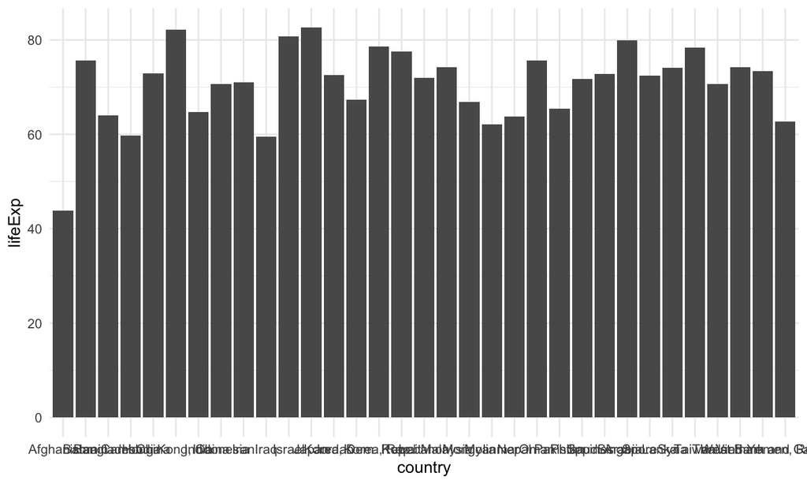

```r
gapminder %>%
    filter(year == 2007, continent == "Asia") %>%
    ggplot(aes(x = country, y = lifeExp)) +
    geom_col() + theme_minimal()
```

## DataViz Advice

USE COLOR ONLY IF THE **NUMBER OF CATEGORIES IS SMALL** (~10 max!)

## Conditional formatting

## Conditional formatting: overview

Several options:

- change the output attributes depending on the level of a value using **if**()!
- code categorical variables with **mutate**() and **ifelse**();
- display output under some condition via **conditionalPanel**().

Including these options are a bit costly in terms of code, but can add value for the user (could be used for password! \(\rightarrow\) exercise).

## if(…){…} => always useful!

Include the condition inside the output module in the server.

```r
output$box1 <- renderValueBox({
    prop <- round(mean(data()$Gender=="Women"), 2)      # Proportion of women
    if(prop < 0.2){colorbox <- "red"}                     # Low proportion: bad
    if(prop > 0.4){colorbox <- "green"}                   # Higher proportion: better
    if(prop >= 0.2 & prop <= 0.4){colorbox <- "yellow"}   # Intermediate proportion: meh
    valueBox(
        value = prop,
        subtitle =  "Proportion of women",
        icon = icon("female", lib = "font-awesome"),
        color = colorbox,
        width = 4  # Width in Bootstrap mode: needs a column()!
    )
})
```

## if_else(*condition*, true, false)

```r
diamonds %>%
    mutate(size_category = if_else(carat < 0.8, "Small",
                                   if_else(carat > 1.5, "Big", "Medium"))) %>%
    select(carat, price, cut, clarity, size_category)
```

|  | carat | price | cut | clarity | size_category |
| --- | --- | --- | --- | --- | --- |
| 1 | 0.7 | 2757 | Very Good | VS2 | Small |
| 2 | 0.72 | 2757 | Premium | SI1 | Small |
| 3 | 0.72 | 2757 | Ideal | SI1 | Small |
| 4 | 0.72 | 2757 | Good | SI1 | Small |
| 5 | 0.7 | 2757 | Very Good | SI1 | Small |
| 6 | 0.86 | 2757 | Premium | SI2 | Medium |
| 7 | 0.75 | 2757 | Ideal | SI2 | Small |

## conditionalPanel

A relatively simple syntax:

```r
dashboardSidebar(
    radioButtons("show", "Show full data (below)",
                                     c("yes" = "yes",
                                       "no" = "no"))
),
dashboardBody(
    ###### NEW ELEMENTS HERE
    conditionalPanel(
        condition = "input.show == 'yes'", # CONDITION (strange syntax)
        DT::dataTableOutput("pt")          # If condition is true...
    )
)
```

## Going further with shiny

## Themes & styles

Many packages can help make your app groovy! Curated lists + book:

- https://github.com/nanxstats/awesome-shiny-extensions
- https://paulvanderlaken.com/2021/02/16/awesome-r-shiny-resources-extensions/

**Examples**:

- time/chronology visualizations: https://daattali.com/shiny/timevis-demo/
- color picking: https://daattali.com/shiny/colourInput/
- custom themes (among other): https://github.com/rstudio/bslib (not working on shinydashboard - yet)
- drag & drop: https://rstudio.github.io/sortable/index.html
- modern UI with **bs4Dash**: https://rinterface.github.io/bs4Dash/index.html

## Going further with html & CSS

First, super simple intros to **HTML** & **CSS**:  
https://developer.mozilla.org/en-US/docs/Learn/Getting_started_with_the_web/HTML_basics https://developer.mozilla.org/en-US/docs/Learn/Getting_started_with_the_web/CSS_basics  
In notebooks & Shiny: http://dataviz-2021.netlify.app/slides/w9p2.html

The source: https://mastering-shiny.org/advanced-ui.html  
The **fresh** package (this one is important!):  
https://cran.r-project.org/web/packages/fresh/vignettes/fresh.html  
https://github.com/dreamRs/fresh  
One example of indirect (non visibly CSS) formatting:

```r
font_avenir <- list(     # This is a formatting variable for plots' fonts
    family = "Avenir",   # This font has a modern look
    size = 9,
    color = 'grey')

p <-  movies %>% ggplot(aes(x = duration, y = imdb_score)) + geom_point()
ggplotly(p) %>%
    layout(title = "Movies", font = font_avenir) # The font avenir is defined above
```

## Going further with ggplot

**General overview**: https://exts.ggplot2.tidyverse.org/gallery/

- ggforce: https://rviews.rstudio.com/2019/09/19/intro-to-ggforce/
- ggforce: https://www.r-bloggers.com/the-ggforce-awakens-again/
- ggradar: https://github.com/ricardo-bion/ggradar
- ggalluvial: https://github.com/corybrunson/ggalluvial
- ggthemes: https://yutannihilation.github.io/allYourFigureAreBelongToUs/ggthemes/
- tvthemes: https://github.com/Ryo-N7/tvthemes
- BBC style: https://github.com/bbc/bbplot; https://bbc.github.io/rcookbook/
- hrbrthemes: https://github.com/hrbrmstr/hrbrthemes
- ggtext: enhanced text management: https://wilkelab.org/ggtext/
- ggrough: https://github.com/xvrdm/ggrough
- **thematic** (important): https://rstudio.github.io/thematic/
- ggCyberpunk: https://github.com/delabj/ggcyberpunk

## Going pro

The apps we develop in the course are “*amateur*”.  
They use the simple principles of **Shiny**.  
If you want to become proficient in building apps, have a look at:

- https://unleash-shiny.rinterface.com/index.html
- https://business-science.github.io/shiny-production-with-aws-book/

## Good looking tables: references

- **DataTable**: https://rstudio.github.io/DT/
- **reactable**: https://glin.github.io/reactable/
- \(+\) formatting! https://github.com/kcuilla/reactablefmtr
- **gt**: https://gt.rstudio.com,  
  https://rpubs.com/jdjohn215/three-way-crosstab-table-with-gt
- **kableExtra**: https://cran.r-project.org/web/packages/kableExtra/index.html
- **formattable**: https://www.displayr.com/formattable/
- **flextable**: https://ardata-fr.github.io/flextable-gallery/gallery/
- R hands on table: https://jrowen.github.io/rhandsontable/

See also:  
https://rfortherestofus.com/2019/11/how-to-make-beautiful-tables-in-r/ https://appsilon.com/forget-about-excel-use-r-shiny-packages-instead/

## Going even further with **Shiny** (this never stops)

**Shiny extensions**:

shinyWidgets: https://github.com/dreamRs/shinyWidgets  
shinydashboardPlus: https://rinterface.github.io/shinydashboardPlus/  
shinyFeedback: https://github.com/merlinoa/shinyFeedback  
argonDash: https://rinterface.github.io/argonDash/index.html

(**from**: https://rinterface.com)

**Animations**:

shinyanimate: https://github.com/Swechhya/shinyanimate  
plotly: https://plotly.com/r/animations/

**Shiny on phones**:

shinyMobile (iOS, Android): https://rinterface.github.io/shinyMobile/

## DashboardPlus & bs4Dash

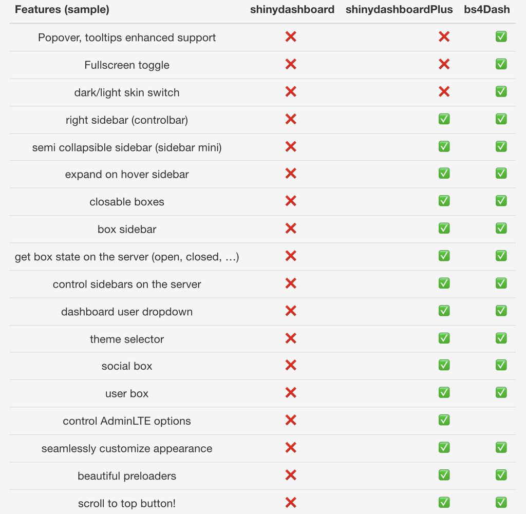

## dashboard - themes

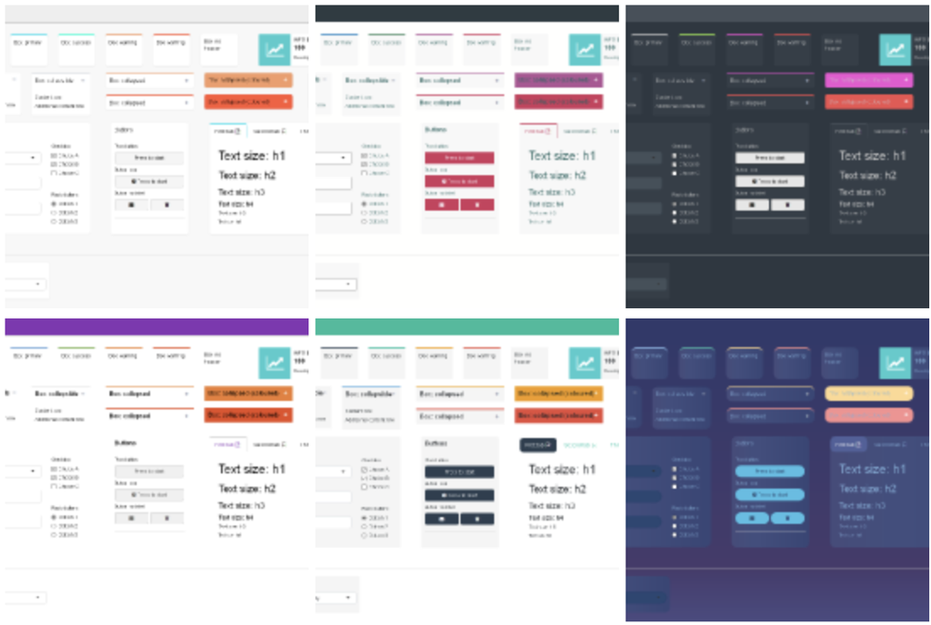

This allows to bypass the CSS code while at the same time allowing a rich variety of options in terms of font and color choice.

Defining each item takes time and colors (back, font, border, etc.) are coded in RGB format. Gradients are available.

example in my app: https://gcoqueret.shinyapps.io/olympics/  
See also: https://rstudio.github.io/shinydashboard/appearance.html

## Summary of important packages

In the maze of all packages, here is the ultimate shortlist:

- **bs4Dash** for modern templates
- **thematic** & **bslib** for global theming (shiny)
- **fresh** for local theming (shinydashboard, bs4Dash)
- **gt** & **reactable** for awesome tables.

Pick your **favorites**!

## Deployment

## Step 1: organize!

Once your app is ready:  
\(>\) if your app is in .Rmd, copy-paste the code and put it a .R script  
\(>\) **CALL** the file “app.R” any other choice may lead to errors!!!  
\(>\) put all files in the same folder: app.R & data file!

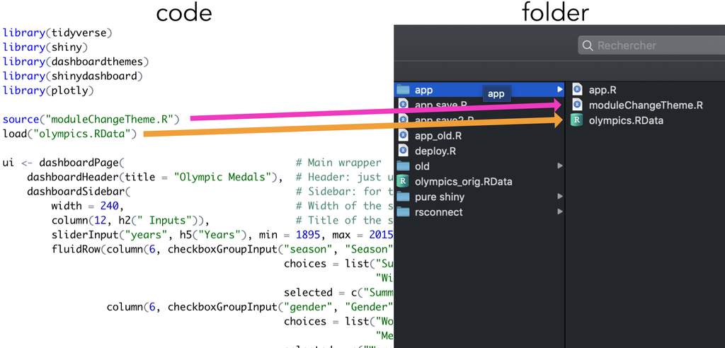

## Step 2: launch your app, and click on “publish”

[figure not shown]

## Step 3: follow the flow

- enter your login & password if/when prompted
- find a short name for your app
- select the correct files (app.R + dataset .RData)
- the deployment usually takes some time (around 1 minute for my apps)

There is another way to proceed, using the *rsconnect* package and the function **deployApp**().  
See https://shiny.rstudio.com/articles/shinyapps.html

This requires a token & a password.

## Inside shinyapps

In the sidebar, in “**Account**”, there is a “Tokens” option.

[figure not shown]

## Advanced topics

(via Google!)

- **Regular update of data** (hint: exogenous source): https://community.rstudio.com/t/using-cron-to-import-data-daily-and-update-shiny-app/24217
- **Scheduling** (via R scripts on Windows): https://github.com/BillPetti/Spray-Chart-Tool
- **Scheduling** (via scheduleR package): https://github.com/Bart6114/scheduleR

## What are your questions?

A ‘bad’ question is better than no question (there are no bad questions).

This was the **last pure Shiny session**: ask for help if need be!

**CODING** an **APP** is **HARD**.

## Your turn!

Two exercises:

1. Deploy your app (or any one app).
2. Pick any existing app and add textInput widget. The user must enter a password in this widget. If the password is correct, the body displays any kind of output (table, plot, etc.)